# The Simpsons - Small Explanatory Data Analysis

Nuray Nasib

# The Simpsons

The Simpsons is an American animated sitcom created by *Matt Groening* for the Fox Broadcasting Company. The series is a satirical depiction of American life, epitomized by the Simpson family, which consists of *Homer, Marge, Bart, Lisa, and Maggie*. The show is set in the fictional town of Springfield and parodies American culture and society, television, and the human condition.

The family was conceived by *Groening* shortly before a solicitation for a series of animated shorts with producer *James L. Brooks*. He created a dysfunctional family and named the characters after his own family members, substituting *Bart* for his own name; he thought Simpson was a funny name in that it sounded similar to “simpleton”. The shorts became a part of *The Tracey Ullman Show* on April 19, 1987. After three seasons, the sketch was developed into a half-hour prime time show and became Fox’s first series to land in the Top 30 ratings in a season (1989–1990).

Since its debut on December 17, 1989, 722 episodes of the show have been broadcast. It is the longest-running American animated series, longest-running American sitcom, and the longest-running American scripted primetime television series, both in terms of seasons and number of episodes. A feature-length film, The Simpsons Movie, was released in theaters worldwide on July 27, 2007, and grossed over $527 million, with a sequel in development as of 2018. The series has also spawned numerous comic book series, video games, books, and other related media, as well as a billion-dollar merchandising industry. The Simpsons is a joint production by Gracie Films and 20th Television. On March 3, 2021, the series was announced to have been renewed for seasons 33 and 34, which were later confirmed to have 22 episodes each, increasing the episode count from 706 to 750. Its thirty-third season premiered on September 26, 2021. Source: [Wikipedia](https://en.wikipedia.org/wiki/The_Simpsons)

[figure not shown]

# Explanatory Data Analysis

```r
library(caret)
library(corrplot)
library(readr)
library(knitr)
library(kableExtra)
library(formattable)
library(dplyr)
library(tm)
library(tidyr)
library(wordcloud)
library(ggplot2)
library(gridExtra)
library(grid)
library(leaflet)
library(randomForest)
library(plotly)
options(knitr.table.format = "html")
```

```r
PATH="C:/Users/Nuray/Desktop/rr/RRcourse2022/RR_Mar_30_31/simpsons-by-the-data"
characters_df <- read_csv(paste0(PATH,'/simpsons_characters.csv'))
episodes_df <- read_csv(paste0(PATH,'/simpsons_episodes.csv'))
locations_df <- read_csv(paste0(PATH,'/simpsons_locations.csv'))
script_lines_df <- read_csv(paste0(PATH,'/simpsons_script_lines.csv'))
```

# Data Summary

We have 4 data files in Simpsons dataset, as following:

- simpsons_characters.csv (6722 rows, 4 columns)
- simpsons_episodes.csv (600 rows, 14 columns)
- simpsons_locations.csv (4459 rows, 3 columns)
- simpsons_script_lines.csv (158271 rows, 13 columns)

Let’s see the first few rows of each data file and also glimpse these data files.

## Characters

```r
knitr::kable(head(characters_df,5),caption="Characters information (first 5 rows)")
```

Characters information (first 5 rows)

| id | name | normalized_name | gender |
| --- | --- | --- | --- |
| 7 | Children | children | NA |
| 12 | Mechanical Santa | mechanical santa | NA |
| 13 | Tattoo Man | tattoo man | NA |
| 16 | DOCTOR ZITSOFSKY | doctor zitsofsky | NA |
| 20 | Students | students | NA |

```r
glimpse(characters_df)
```

```
## Rows: 6,722
## Columns: 4
## $ id              <dbl> 7, 12, 13, 16, 20, 24, 26, 27, 29, 30, 34, 35, 36, 37,~
## $ name            <chr> "Children", "Mechanical Santa", "Tattoo Man", "DOCTOR ~
## $ normalized_name <chr> "children", "mechanical santa", "tattoo man", "doctor ~
## $ gender          <chr> NA, NA, NA, NA, NA, NA, NA, NA, NA, NA, NA, NA, NA, NA~
```

## Episodes

```r
knitr::kable(head(episodes_df,5),caption="Episodes information (first 5 rows)")
```

Episodes information (first 5 rows)

| id | image_url | imdb_rating | imdb_votes | number_in_season | number_in_series | original_air_date | original_air_year | production_code | season | title | us_viewers_in_millions | video_url | views |
| --- | --- | --- | --- | --- | --- | --- | --- | --- | --- | --- | --- | --- | --- |
| 10 | http://static-media.fxx.com/img/FX_Networks_-_FXX/305/815/Simpsons_01_10.jpg | 7.4 | 1511 | 10 | 10 | 1990-03-25 | 1990 | 7G10 | 1 | Homer’s Night Out | 30.3 | http://www.simpsonsworld.com/video/275197507879 | 50816 |
| 12 | http://static-media.fxx.com/img/FX_Networks_-_FXX/245/843/Simpsons_01_12.jpg | 8.3 | 1716 | 12 | 12 | 1990-04-29 | 1990 | 7G12 | 1 | Krusty Gets Busted | 30.4 | http://www.simpsonsworld.com/video/288019523914 | 62561 |
| 14 | http://static-media.fxx.com/img/FX_Networks_-_FXX/662/811/bart_gets_F.jpg | 8.2 | 1638 | 1 | 14 | 1990-10-11 | 1990 | 7F03 | 2 | Bart Gets an “F” | 33.6 | http://www.simpsonsworld.com/video/260539459671 | 59575 |
| 17 | http://static-media.fxx.com/img/FX_Networks_-_FXX/660/859/Simpsons_02_01.jpg | 8.1 | 1457 | 4 | 17 | 1990-11-01 | 1990 | 7F01 | 2 | Two Cars in Every Garage and Three Eyes on Every Fish | 26.1 | http://www.simpsonsworld.com/video/260537411822 | 64959 |
| 19 | http://static-media.fxx.com/img/FX_Networks_-_FXX/662/811/Simpsons_02_08.jpg | 8.0 | 1366 | 6 | 19 | 1990-11-15 | 1990 | 7F08 | 2 | Dead Putting Society | 25.4 | http://www.simpsonsworld.com/video/260539459670 | 50691 |

```r
glimpse(episodes_df)
```

```
## Rows: 600
## Columns: 14
## $ id                     <dbl> 10, 12, 14, 17, 19, 21, 23, 26, 28, 30, 32, 35,~
## $ image_url              <chr> "http://static-media.fxx.com/img/FX_Networks_-_~
## $ imdb_rating            <dbl> 7.4, 8.3, 8.2, 8.1, 8.0, 8.4, 7.8, 8.0, 8.2, 7.~
## $ imdb_votes             <dbl> 1511, 1716, 1638, 1457, 1366, 1522, 1340, 1329,~
## $ number_in_season       <dbl> 10, 12, 1, 4, 6, 8, 10, 13, 15, 17, 19, 22, 2, ~
## $ number_in_series       <dbl> 10, 12, 14, 17, 19, 21, 23, 26, 28, 30, 32, 35,~
## $ original_air_date      <date> 1990-03-25, 1990-04-29, 1990-10-11, 1990-11-01~
## $ original_air_year      <dbl> 1990, 1990, 1990, 1990, 1990, 1990, 1991, 1991,~
## $ production_code        <chr> "7G10", "7G12", "7F03", "7F01", "7F08", "7F06",~
## $ season                 <dbl> 1, 1, 2, 2, 2, 2, 2, 2, 2, 2, 2, 2, 3, 3, 3, 3,~
## $ title                  <chr> "Homer's Night Out", "Krusty Gets Busted", "Bar~
## $ us_viewers_in_millions <dbl> 30.3, 30.4, 33.6, 26.1, 25.4, 26.2, 24.8, 26.2,~
## $ video_url              <chr> "http://www.simpsonsworld.com/video/27519750787~
## $ views                  <dbl> 50816, 62561, 59575, 64959, 50691, 57605, 56486~
```

## Locations

```r
knitr::kable(head(locations_df,5),caption="Locations information (first 5 rows)")
```

Locations information (first 5 rows)

| id | name | normalized_name |
| --- | --- | --- |
| 1 | Street | street |
| 2 | Car | car |
| 3 | Springfield Elementary School | springfield elementary school |
| 4 | Auditorium | auditorium |
| 5 | Simpson Home | simpson home |

```r
glimpse(locations_df)
```

```
## Rows: 4,459
## Columns: 3
## $ id              <dbl> 1, 2, 3, 4, 5, 6, 7, 8, 9, 10, 11, 12, 13, 14, 15, 16,~
## $ name            <chr> "Street", "Car", "Springfield Elementary School", "Aud~
## $ normalized_name <chr> "street", "car", "springfield elementary school", "aud~
```

## Script lines

```r
knitr::kable(head(script_lines_df,5),caption="Script lines details (first 5 rows)")
```

Script lines details (first 5 rows)

| id | episode_id | number | raw_text | timestamp_in_ms | speaking_line | character_id | location_id | raw_character_text | raw_location_text | spoken_words | normalized_text | word_count |
| --- | --- | --- | --- | --- | --- | --- | --- | --- | --- | --- | --- | --- |
| 9549 | 32 | 209 | Miss Hoover: No, actually, it was a little of both. Sometimes when a disease is in all the magazines and all the news shows, it’s only natural that you think you have it. | 848000 | TRUE | 464 | 3 | Miss Hoover | Springfield Elementary School | No, actually, it was a little of both. Sometimes when a disease is in all the magazines and all the news shows, it’s only natural that you think you have it. | no actually it was a little of both sometimes when a disease is in all the magazines and all the news shows its only natural that you think you have it | 31 |
| 9550 | 32 | 210 | Lisa Simpson: (NEAR TEARS) Where’s Mr. Bergstrom? | 856000 | TRUE | 9 | 3 | Lisa Simpson | Springfield Elementary School | Where’s Mr. Bergstrom? | wheres mr bergstrom | 3 |
| 9551 | 32 | 211 | Miss Hoover: I don’t know. Although I’d sure like to talk to him. He didn’t touch my lesson plan. What did he teach you? | 856000 | TRUE | 464 | 3 | Miss Hoover | Springfield Elementary School | I don’t know. Although I’d sure like to talk to him. He didn’t touch my lesson plan. What did he teach you? | i dont know although id sure like to talk to him he didnt touch my lesson plan what did he teach you | 22 |
| 9552 | 32 | 212 | Lisa Simpson: That life is worth living. | 864000 | TRUE | 9 | 3 | Lisa Simpson | Springfield Elementary School | That life is worth living. | that life is worth living | 5 |
| 9553 | 32 | 213 | Edna Krabappel-Flanders: The polls will be open from now until the end of recess. Now, (SOUR) just in case any of you have decided to put any thought into this, we’ll have our final statements. Martin… | 864000 | TRUE | 40 | 3 | Edna Krabappel-Flanders | Springfield Elementary School | The polls will be open from now until the end of recess. Now, just in case any of you have decided to put any thought into this, we’ll have our final statements. Martin? | the polls will be open from now until the end of recess now just in case any of you have decided to put any thought into this well have our final statements martin | 33 |

```r
glimpse(script_lines_df)
```

```
## Rows: 158,271
## Columns: 13
## $ id                 <dbl> 9549, 9550, 9551, 9552, 9553, 9554, 9555, 9556, 955~
## $ episode_id         <dbl> 32, 32, 32, 32, 32, 32, 32, 32, 32, 32, 32, 32, 32,~
## $ number             <dbl> 209, 210, 211, 212, 213, 214, 215, 216, 217, 218, 2~
## $ raw_text           <chr> "Miss Hoover: No, actually, it was a little of both~
## $ timestamp_in_ms    <dbl> 848000, 856000, 856000, 864000, 864000, 877000, 881~
## $ speaking_line      <lgl> TRUE, TRUE, TRUE, TRUE, TRUE, TRUE, TRUE, TRUE, FAL~
## $ character_id       <dbl> 464, 9, 464, 9, 40, 38, 40, 8, NA, 9, 469, 9, 469, ~
## $ location_id        <dbl> 3, 3, 3, 3, 3, 3, 3, 3, 374, 374, 374, 374, 374, 37~
## $ raw_character_text <chr> "Miss Hoover", "Lisa Simpson", "Miss Hoover", "Lisa~
## $ raw_location_text  <chr> "Springfield Elementary School", "Springfield Eleme~
## $ spoken_words       <chr> "No, actually, it was a little of both. Sometimes w~
## $ normalized_text    <chr> "no actually it was a little of both sometimes when~
## $ word_count         <dbl> 31, 3, 22, 5, 33, 8, 1, 5, NA, 4, 19, 8, 10, 9, 19,~
```

# Viewership

In the graph below US viewers (millions) are represented per episode and per season.

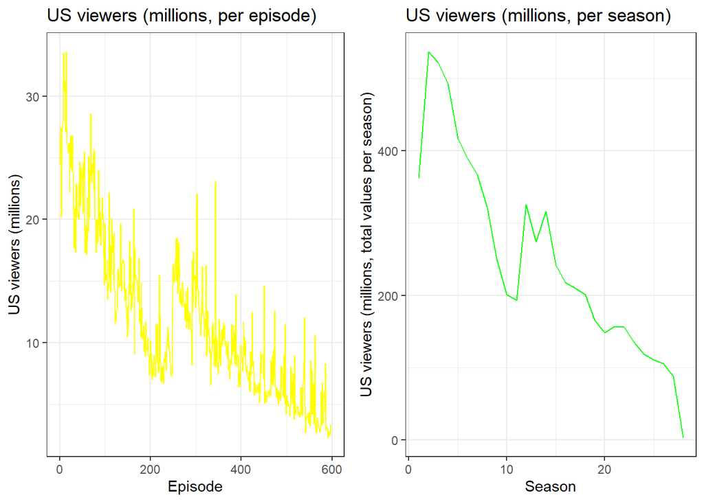

```r
episodes_df[complete.cases(episodes_df), ] %>%
ggplot(aes(x = id, y = us_viewers_in_millions)) +
  geom_line(col="yellow") + theme_bw() + theme(legend.position="right") +
  labs(x="Episode", y="US viewers (millions)",
       title="US viewers (millions, per episode)") ->d1
episodes_df[complete.cases(episodes_df), ] %>% group_by(season) %>% summarize(nr = sum(us_viewers_in_millions)) %>% ungroup() %>%
ggplot(aes(x = season, y = nr)) +
  geom_line(col="green") + theme_bw() + theme(legend.position="right") +
  labs(x="Season", y="US viewers (millions, total values per season)",
       title="US viewers (millions, per season)") -> d2
grid.arrange(d1, d2, ncol=2)
```

Boxplot graph for US viewers/episode grouped by season.

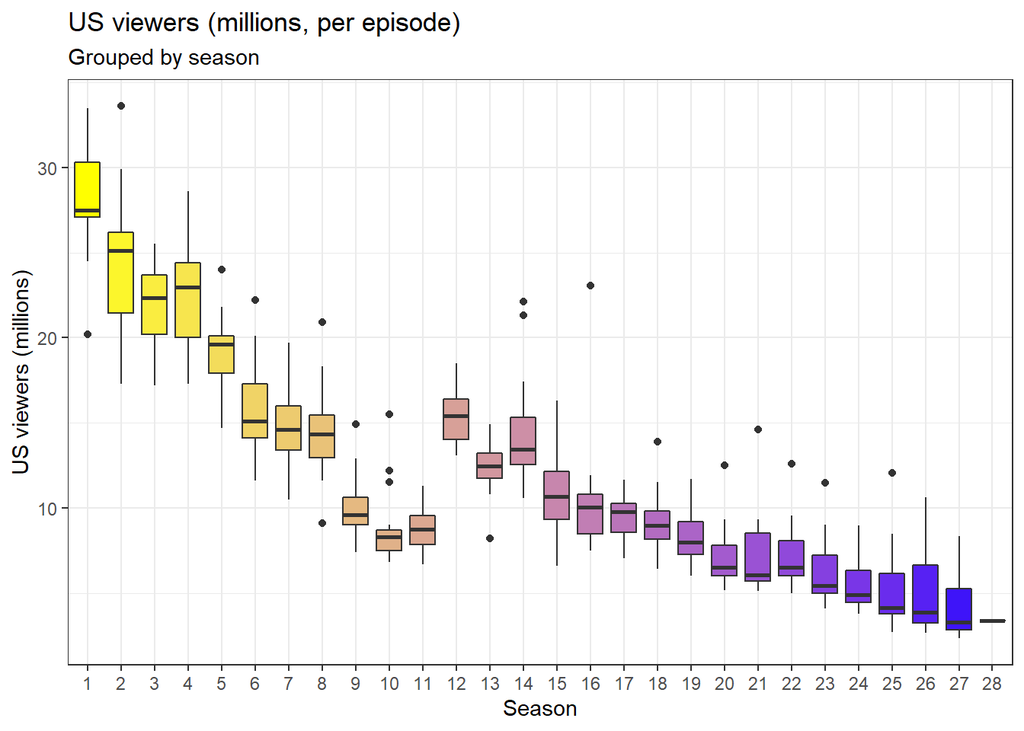

```r
episodes_df[complete.cases(episodes_df), ] %>%
ggplot(aes(x = reorder(season,season), y = us_viewers_in_millions, fill=season)) +  guides(fill=FALSE) +
  geom_boxplot() + theme_bw() +  scale_fill_gradient(low = "yellow", high = "blue")+
  labs(x="Season", y="US viewers (millions)",  fill="Season",
       title="US viewers (millions, per episode)", subtitle="Grouped by season")
```

We’ve noticed a general decline in viewership. Older seasons appear to be the most popular, praised, and viewed. In truth, The Simpsons gained critical acclaim throughout its first nine or ten seasons, which are widely regarded as the show’s “Golden Age,” but has been criticized for a perceived deterioration in quality over time.

To be fair, the recent availability of a variety of network channels and Internet streaming services has resulted in a systematic reduction in the number of TV viewers for many series, not just The Simpsons.